# Breast Cancer Detection

## Importing libraries and dataset

```python
#Importing libraries

import pandas as pd
import numpy as np
import matplotlib.pyplot as plt
import seaborn as sns
```

```python
#Loading dataset

from sklearn.datasets import load_breast_cancer
```

```python
cancer = load_breast_cancer()
```

```python
cancer.keys()
```

```
dict_keys(['data', 'target', 'target_names', 'DESCR', 'feature_names', 'filename'])
```

```python
print(cancer['DESCR'])
```

```
.. _breast_cancer_dataset:

Breast cancer wisconsin (diagnostic) dataset
--------------------------------------------

**Data Set Characteristics:**

    :Number of Instances: 569

    :Number of Attributes: 30 numeric, predictive attributes and the class

    :Attribute Information:
        - radius (mean of distances from center to points on the perimeter)
        - texture (standard deviation of gray-scale values)
        - perimeter
        - area
        - smoothness (local variation in radius lengths)
        - compactness (perimeter^2 / area - 1.0)
        - concavity (severity of concave portions of the contour)
        - concave points (number of concave portions of the contour)
        - symmetry
        - fractal dimension ("coastline approximation" - 1)

        The mean, standard error, and "worst" or largest (mean of the three
        largest values) of these features were computed for each image,
        resulting in 30 features.  For instance, field 3 is Mean Radius, field
        13 is Radius SE, field 23 is Worst Radius.

        - class:
                - WDBC-Malignant
                - WDBC-Benign

    :Summary Statistics:

    ===================================== ====== ======
                                           Min    Max
    ===================================== ====== ======
    radius (mean):                        6.981  28.11
    texture (mean):                       9.71   39.28
    perimeter (mean):                     43.79  188.5
```

[output cut: 63 more lines]

```
ftp ftp.cs.wisc.edu
cd math-prog/cpo-dataset/machine-learn/WDBC/

.. topic:: References

   - W.N. Street, W.H. Wolberg and O.L. Mangasarian. Nuclear feature extraction
     for breast tumor diagnosis. IS&T/SPIE 1993 International Symposium on
     Electronic Imaging: Science and Technology, volume 1905, pages 861-870,
     San Jose, CA, 1993.
   - O.L. Mangasarian, W.N. Street and W.H. Wolberg. Breast cancer diagnosis and
     prognosis via linear programming. Operations Research, 43(4), pages 570-577,
     July-August 1995.
   - W.H. Wolberg, W.N. Street, and O.L. Mangasarian. Machine learning techniques
     to diagnose breast cancer from fine-needle aspirates. Cancer Letters 77 (1994)
     163-171.
```

```python
print(cancer['target_names'])
```

```
['malignant' 'benign']
```

```python
print(cancer['target'])
```

```
[0 0 0 0 0 0 0 0 0 0 0 0 0 0 0 0 0 0 0 1 1 1 0 0 0 0 0 0 0 0 0 0 0 0 0 0 0
 1 0 0 0 0 0 0 0 0 1 0 1 1 1 1 1 0 0 1 0 0 1 1 1 1 0 1 0 0 1 1 1 1 0 1 0 0
 1 0 1 0 0 1 1 1 0 0 1 0 0 0 1 1 1 0 1 1 0 0 1 1 1 0 0 1 1 1 1 0 1 1 0 1 1
 1 1 1 1 1 1 0 0 0 1 0 0 1 1 1 0 0 1 0 1 0 0 1 0 0 1 1 0 1 1 0 1 1 1 1 0 1
 1 1 1 1 1 1 1 1 0 1 1 1 1 0 0 1 0 1 1 0 0 1 1 0 0 1 1 1 1 0 1 1 0 0 0 1 0
 1 0 1 1 1 0 1 1 0 0 1 0 0 0 0 1 0 0 0 1 0 1 0 1 1 0 1 0 0 0 0 1 1 0 0 1 1
 1 0 1 1 1 1 1 0 0 1 1 0 1 1 0 0 1 0 1 1 1 1 0 1 1 1 1 1 0 1 0 0 0 0 0 0 0
 0 0 0 0 0 0 0 1 1 1 1 1 1 0 1 0 1 1 0 1 1 0 1 0 0 1 1 1 1 1 1 1 1 1 1 1 1
 1 0 1 1 0 1 0 1 1 1 1 1 1 1 1 1 1 1 1 1 1 0 1 1 1 0 1 0 1 1 1 1 0 0 0 1 1
 1 1 0 1 0 1 0 1 1 1 0 1 1 1 1 1 1 1 0 0 0 1 1 1 1 1 1 1 1 1 1 1 0 0 1 0 0
 0 1 0 0 1 1 1 1 1 0 1 1 1 1 1 0 1 1 1 0 1 1 0 0 1 1 1 1 1 1 0 1 1 1 1 1 1
 1 0 1 1 1 1 1 0 1 1 0 1 1 1 1 1 1 1 1 1 1 1 1 0 1 0 0 1 0 1 1 1 1 1 0 1 1
 0 1 0 1 1 0 1 0 1 1 1 1 1 1 1 1 0 0 1 1 1 1 1 1 0 1 1 1 1 1 1 1 1 1 1 0 1
 1 1 1 1 1 1 0 1 0 1 1 0 1 1 1 1 1 0 0 1 0 1 0 1 1 1 1 1 0 1 1 0 1 0 1 0 0
 1 1 1 0 1 1 1 1 1 1 1 1 1 1 1 0 1 0 0 1 1 1 1 1 1 1 1 1 1 1 1 1 1 1 1 1 1
 1 1 1 1 1 1 1 0 0 0 0 0 0 1]
```

```python
cancer['data'].shape
```

```
(569, 30)
```

```python
#Save this in a dataframe for further analysis

df_cancer=pd.DataFrame(np.c_[cancer['data'],cancer['target']],columns=np.append(cancer['feature_names'],'target'))
```

```python
df_cancer.head()
```

|  | mean radius | mean texture | mean perimeter | mean area | mean smoothness | mean compactness | mean concavity | mean concave points | mean symmetry | mean fractal dimension | ... | worst texture | worst perimeter | worst area | worst smoothness | worst compactness | worst concavity | worst concave points | worst symmetry | worst fractal dimension | target |
| --- | --- | --- | --- | --- | --- | --- | --- | --- | --- | --- | --- | --- | --- | --- | --- | --- | --- | --- | --- | --- | --- |
| 0 | 17.99 | 10.38 | 122.80 | 1001.0 | 0.11840 | 0.27760 | 0.3001 | 0.14710 | 0.2419 | 0.07871 | ... | 17.33 | 184.60 | 2019.0 | 0.1622 | 0.6656 | 0.7119 | 0.2654 | 0.4601 | 0.11890 | 0.0 |
| 1 | 20.57 | 17.77 | 132.90 | 1326.0 | 0.08474 | 0.07864 | 0.0869 | 0.07017 | 0.1812 | 0.05667 | ... | 23.41 | 158.80 | 1956.0 | 0.1238 | 0.1866 | 0.2416 | 0.1860 | 0.2750 | 0.08902 | 0.0 |
| 2 | 19.69 | 21.25 | 130.00 | 1203.0 | 0.10960 | 0.15990 | 0.1974 | 0.12790 | 0.2069 | 0.05999 | ... | 25.53 | 152.50 | 1709.0 | 0.1444 | 0.4245 | 0.4504 | 0.2430 | 0.3613 | 0.08758 | 0.0 |
| 3 | 11.42 | 20.38 | 77.58 | 386.1 | 0.14250 | 0.28390 | 0.2414 | 0.10520 | 0.2597 | 0.09744 | ... | 26.50 | 98.87 | 567.7 | 0.2098 | 0.8663 | 0.6869 | 0.2575 | 0.6638 | 0.17300 | 0.0 |
| 4 | 20.29 | 14.34 | 135.10 | 1297.0 | 0.10030 | 0.13280 | 0.1980 | 0.10430 | 0.1809 | 0.05883 | ... | 16.67 | 152.20 | 1575.0 | 0.1374 | 0.2050 | 0.4000 | 0.1625 | 0.2364 | 0.07678 | 0.0 |

5 rows × 31 columns

```python
df_cancer.tail()
```

|  | mean radius | mean texture | mean perimeter | mean area | mean smoothness | mean compactness | mean concavity | mean concave points | mean symmetry | mean fractal dimension | ... | worst texture | worst perimeter | worst area | worst smoothness | worst compactness | worst concavity | worst concave points | worst symmetry | worst fractal dimension | target |
| --- | --- | --- | --- | --- | --- | --- | --- | --- | --- | --- | --- | --- | --- | --- | --- | --- | --- | --- | --- | --- | --- |
| 564 | 21.56 | 22.39 | 142.00 | 1479.0 | 0.11100 | 0.11590 | 0.24390 | 0.13890 | 0.1726 | 0.05623 | ... | 26.40 | 166.10 | 2027.0 | 0.14100 | 0.21130 | 0.4107 | 0.2216 | 0.2060 | 0.07115 | 0.0 |
| 565 | 20.13 | 28.25 | 131.20 | 1261.0 | 0.09780 | 0.10340 | 0.14400 | 0.09791 | 0.1752 | 0.05533 | ... | 38.25 | 155.00 | 1731.0 | 0.11660 | 0.19220 | 0.3215 | 0.1628 | 0.2572 | 0.06637 | 0.0 |
| 566 | 16.60 | 28.08 | 108.30 | 858.1 | 0.08455 | 0.10230 | 0.09251 | 0.05302 | 0.1590 | 0.05648 | ... | 34.12 | 126.70 | 1124.0 | 0.11390 | 0.30940 | 0.3403 | 0.1418 | 0.2218 | 0.07820 | 0.0 |
| 567 | 20.60 | 29.33 | 140.10 | 1265.0 | 0.11780 | 0.27700 | 0.35140 | 0.15200 | 0.2397 | 0.07016 | ... | 39.42 | 184.60 | 1821.0 | 0.16500 | 0.86810 | 0.9387 | 0.2650 | 0.4087 | 0.12400 | 0.0 |
| 568 | 7.76 | 24.54 | 47.92 | 181.0 | 0.05263 | 0.04362 | 0.00000 | 0.00000 | 0.1587 | 0.05884 | ... | 30.37 | 59.16 | 268.6 | 0.08996 | 0.06444 | 0.0000 | 0.0000 | 0.2871 | 0.07039 | 1.0 |

5 rows × 31 columns

## Visualizing the Data

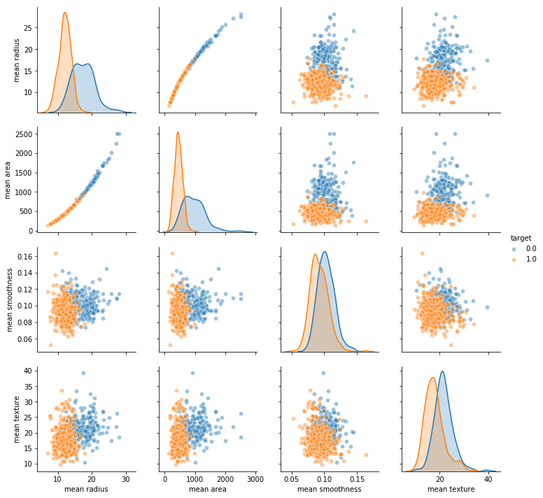

```python
sns.pairplot(df_cancer,vars=['mean radius','mean area','mean smoothness','mean texture'], hue='target',plot_kws={'alpha':0.45})
```

### Insights

1. Mean radius of benign(1) tumours is lesser than that of cancerous tumours.
2. Area follows the same trend since area is proportional to radius.
3. Mean smoothness/texture vs mean radius/area also show linearly separable regions.

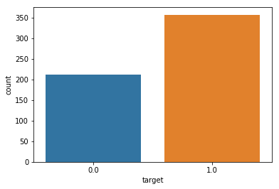

```python
sns.countplot(df_cancer['target'],label='count')
```

### Insights

1. Benign tumours outnumber cancerous tumours.
2. Nearly double.

```python
df_cancer['target'].value_counts()
```

```
1.0    357
0.0    212
Name: target, dtype: int64
```

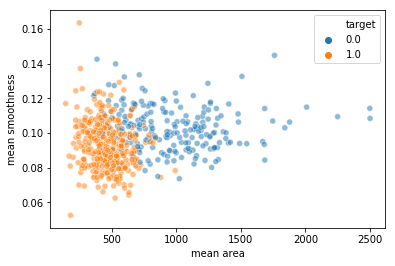

```python
sns.scatterplot(x='mean area',y='mean smoothness',hue='target',alpha=0.50,data=df_cancer)
```

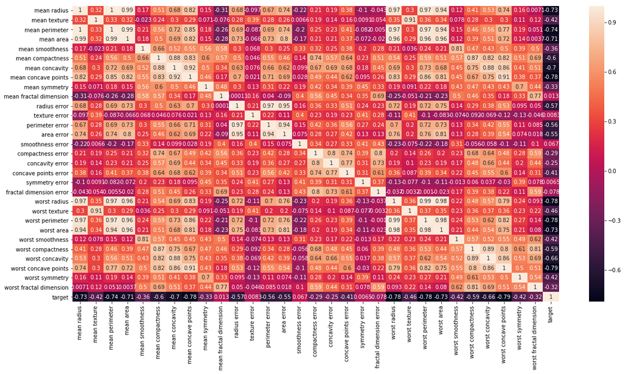

```python
plt.figure(figsize=(20,10))
sns.heatmap(df_cancer.corr(), annot=True)
```

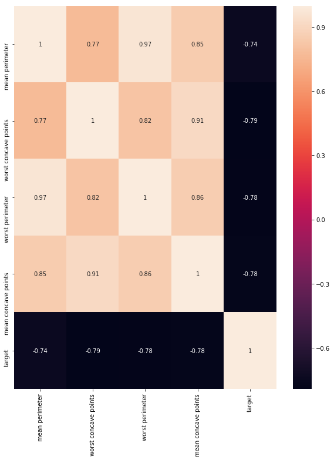

```python
fig = plt.figure(figsize=(10,12))
fig = sns.heatmap(df_cancer[['mean perimeter','worst concave points','worst perimeter','mean concave points','target']].corr(),annot=True)
```

### Insights

The features in second correlation matrix are the ones that have high correlations with target. Note: Correlation not necessarily != Causation

## Model Building

```python
X=df_cancer.iloc[:,:-1]
print(X.columns)
print(X.shape)
```

```
Index(['mean radius', 'mean texture', 'mean perimeter', 'mean area',
       'mean smoothness', 'mean compactness', 'mean concavity',
       'mean concave points', 'mean symmetry', 'mean fractal dimension',
       'radius error', 'texture error', 'perimeter error', 'area error',
       'smoothness error', 'compactness error', 'concavity error',
       'concave points error', 'symmetry error', 'fractal dimension error',
       'worst radius', 'worst texture', 'worst perimeter', 'worst area',
       'worst smoothness', 'worst compactness', 'worst concavity',
       'worst concave points', 'worst symmetry', 'worst fractal dimension'],
      dtype='object')
(569, 30)
```

```python
y=df_cancer['target']
print(y.shape)
```

```
(569,)
```

```python
from sklearn.model_selection import train_test_split
X_train,X_test,y_train,y_test=train_test_split(X,y,test_size=0.2,random_state=0)
```

```python
X_train.head()
```

|  | mean radius | mean texture | mean perimeter | mean area | mean smoothness | mean compactness | mean concavity | mean concave points | mean symmetry | mean fractal dimension | ... | worst radius | worst texture | worst perimeter | worst area | worst smoothness | worst compactness | worst concavity | worst concave points | worst symmetry | worst fractal dimension |
| --- | --- | --- | --- | --- | --- | --- | --- | --- | --- | --- | --- | --- | --- | --- | --- | --- | --- | --- | --- | --- | --- |
| 338 | 10.05 | 17.53 | 64.41 | 310.8 | 0.10070 | 0.07326 | 0.02511 | 0.01775 | 0.1890 | 0.06331 | ... | 11.16 | 26.84 | 71.98 | 384.0 | 0.1402 | 0.14020 | 0.1055 | 0.06499 | 0.2894 | 0.07664 |
| 427 | 10.80 | 21.98 | 68.79 | 359.9 | 0.08801 | 0.05743 | 0.03614 | 0.01404 | 0.2016 | 0.05977 | ... | 12.76 | 32.04 | 83.69 | 489.5 | 0.1303 | 0.16960 | 0.1927 | 0.07485 | 0.2965 | 0.07662 |
| 406 | 16.14 | 14.86 | 104.30 | 800.0 | 0.09495 | 0.08501 | 0.05500 | 0.04528 | 0.1735 | 0.05875 | ... | 17.71 | 19.58 | 115.90 | 947.9 | 0.1206 | 0.17220 | 0.2310 | 0.11290 | 0.2778 | 0.07012 |
| 96 | 12.18 | 17.84 | 77.79 | 451.1 | 0.10450 | 0.07057 | 0.02490 | 0.02941 | 0.1900 | 0.06635 | ... | 12.83 | 20.92 | 82.14 | 495.2 | 0.1140 | 0.09358 | 0.0498 | 0.05882 | 0.2227 | 0.07376 |
| 490 | 12.25 | 22.44 | 78.18 | 466.5 | 0.08192 | 0.05200 | 0.01714 | 0.01261 | 0.1544 | 0.05976 | ... | 14.17 | 31.99 | 92.74 | 622.9 | 0.1256 | 0.18040 | 0.1230 | 0.06335 | 0.3100 | 0.08203 |

5 rows × 30 columns

#### The model we are going to use is SVM. The main advantage of scaling is to avoid attributes in greater numeric ranges dominating those in smaller numeric ranges. Another advantage is to avoid numerical difficulties during the calculation. Because kernel values usually depend on the inner products of feature vectors, e.g. the linear kernel and the polynomial ker- nel, large attribute values might cause numerical problems. Recommended: linearly scaling each attribute to the range [-1,+1] or [0,1].

#### Here MinMaxScaler is used. Output range is [0,1]. Outliers are not affected. Minimum distortion or loss of information.

```python
from sklearn.preprocessing import MinMaxScaler
scaler=MinMaxScaler()
X_train=scaler.fit_transform(X_train)
X_test=scaler.transform(X_test)
```

```python
pd.DataFrame(X_train).head()
```

|  | 0 | 1 | 2 | 3 | 4 | 5 | 6 | 7 | 8 | 9 | ... | 20 | 21 | 22 | 23 | 24 | 25 | 26 | 27 | 28 | 29 |
| --- | --- | --- | --- | --- | --- | --- | --- | --- | --- | --- | --- | --- | --- | --- | --- | --- | --- | --- | --- | --- | --- |
| 0 | 0.145251 | 0.324481 | 0.142492 | 0.070965 | 0.522103 | 0.184508 | 0.058833 | 0.088221 | 0.419192 | 0.281171 | ... | 0.114906 | 0.394989 | 0.107426 | 0.048860 | 0.455854 | 0.109546 | 0.084265 | 0.223872 | 0.261975 | 0.141677 |
| 1 | 0.180747 | 0.509129 | 0.172759 | 0.091792 | 0.384273 | 0.130299 | 0.084677 | 0.069781 | 0.482828 | 0.206613 | ... | 0.171825 | 0.533582 | 0.165745 | 0.074789 | 0.390477 | 0.138070 | 0.153914 | 0.257837 | 0.275971 | 0.141545 |
| 2 | 0.433480 | 0.213693 | 0.418147 | 0.278473 | 0.459650 | 0.224745 | 0.128866 | 0.225050 | 0.340909 | 0.185131 | ... | 0.347919 | 0.201493 | 0.326162 | 0.187451 | 0.326421 | 0.140592 | 0.184505 | 0.388908 | 0.239109 | 0.098911 |
| 3 | 0.246060 | 0.337344 | 0.234953 | 0.130477 | 0.563376 | 0.175296 | 0.058341 | 0.146173 | 0.424242 | 0.345198 | ... | 0.174315 | 0.237207 | 0.158026 | 0.076190 | 0.282837 | 0.064315 | 0.039776 | 0.202618 | 0.130495 | 0.122786 |
| 4 | 0.249373 | 0.528216 | 0.237648 | 0.137010 | 0.318128 | 0.111705 | 0.040159 | 0.062674 | 0.244444 | 0.206403 | ... | 0.221985 | 0.532249 | 0.210817 | 0.107575 | 0.359440 | 0.148548 | 0.098243 | 0.218223 | 0.302582 | 0.177030 |

5 rows × 30 columns

```python
#Building a SUPPORT VECTOR MACHINE classifier

from sklearn.svm import SVC
classifier=SVC(kernel='linear',random_state=0)
```

```python
classifier.fit(X_train,y_train)
```

```
SVC(C=1.0, cache_size=200, class_weight=None, coef0=0.0,
  decision_function_shape='ovr', degree=3, gamma='auto_deprecated',
  kernel='linear', max_iter=-1, probability=False, random_state=0,
  shrinking=True, tol=0.001, verbose=False)
```

```python
y_pred=classifier.predict(X_test)
```

```python
from sklearn.metrics import confusion_matrix,classification_report
cm=confusion_matrix(y_test,y_pred)
report=classification_report(y_test,y_pred)
```

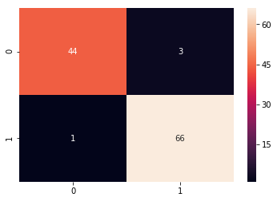

```python
sns.heatmap(cm,annot=True)
```

```python
print(report)
```

```
              precision    recall  f1-score   support

         0.0       0.98      0.94      0.96        47
         1.0       0.96      0.99      0.97        67

   micro avg       0.96      0.96      0.96       114
   macro avg       0.97      0.96      0.96       114
weighted avg       0.97      0.96      0.96       114
```

#### Cross Validation

```python
from sklearn.model_selection import cross_val_score
accuracies=cross_val_score(estimator=classifier,X=X_train,y=y_train,cv=10,n_jobs=-1,scoring='accuracy',verbose=True)
```

```
[Parallel(n_jobs=-1)]: Using backend LokyBackend with 4 concurrent workers.
[Parallel(n_jobs=-1)]: Done  10 out of  10 | elapsed:    2.7s finished
```

```python
print('Mean accuracy is {:.2f} and standard deviation is {:.2f}'.format(accuracies.mean(),accuracies.std()))
```

```
Mean accuracy is 0.97 and standard deviation is 0.02
```

```python
from sklearn.model_selection import GridSearchCV
parameters=[{'C':[0.1,10,100,1000],'kernel':['linear']},{'C':[0.1,10,100,1000],'kernel':['rbf'],'gamma':[1, 0.1, 0.01, 0.001]}]
grid=GridSearchCV(estimator=SVC(),param_grid=parameters,scoring='accuracy',cv=10,n_jobs=-1,refit=True,verbose=True,iid=True)
```

```python
grid.fit(X_train,y_train)
```

```
[Parallel(n_jobs=-1)]: Using backend LokyBackend with 4 concurrent workers.
```

```
Fitting 10 folds for each of 20 candidates, totalling 200 fits
```

```
[Parallel(n_jobs=-1)]: Done 200 out of 200 | elapsed:    0.8s finished
```

```
GridSearchCV(cv=10, error_score='raise-deprecating',
       estimator=SVC(C=1.0, cache_size=200, class_weight=None, coef0=0.0,
  decision_function_shape='ovr', degree=3, gamma='auto_deprecated',
  kernel='rbf', max_iter=-1, probability=False, random_state=None,
  shrinking=True, tol=0.001, verbose=False),
       fit_params=None, iid=True, n_jobs=-1,
       param_grid=[{'C': [0.1, 10, 100, 1000], 'kernel': ['linear']}, {'C': [0.1, 10, 100, 1000], 'kernel': ['rbf'], 'gamma': [1, 0.1, 0.01, 0.001]}],
       pre_dispatch='2*n_jobs', refit=True, return_train_score='warn',
       scoring='accuracy', verbose=True)
```

```python
grid.best_estimator_
```

```
SVC(C=10, cache_size=200, class_weight=None, coef0=0.0,
  decision_function_shape='ovr', degree=3, gamma=1, kernel='rbf',
  max_iter=-1, probability=False, random_state=None, shrinking=True,
  tol=0.001, verbose=False)
```

```python
grid.best_params_
```

```
{'C': 10, 'gamma': 1, 'kernel': 'rbf'}
```

```python
best_estimator=grid.best_estimator_
y_pred_tuned=best_estimator.predict(X_test)
```

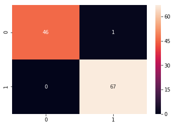

```python
cm_tuned=confusion_matrix(y_test,y_pred_tuned)
sns.heatmap(cm_tuned,annot=True)
```

```python
print(classification_report(y_test,y_pred_tuned))
```

```
              precision    recall  f1-score   support

         0.0       1.00      0.98      0.99        47
         1.0       0.99      1.00      0.99        67

   micro avg       0.99      0.99      0.99       114
   macro avg       0.99      0.99      0.99       114
weighted avg       0.99      0.99      0.99       114
```

```python
from sklearn.model_selection import cross_val_score
accuracies=cross_val_score(estimator=best_estimator,X=X_train,y=y_train,cv=10,n_jobs=-1,scoring='accuracy',verbose=True)
print('Mean accuracy is {:.2f} and standard deviation is {:.2f}'.format(accuracies.mean(),accuracies.std()))
```

```
Mean accuracy is 0.98 and standard deviation is 0.02
```

```
[Parallel(n_jobs=-1)]: Using backend LokyBackend with 4 concurrent workers.
[Parallel(n_jobs=-1)]: Done   3 out of  10 | elapsed:    0.0s remaining:    0.1s
[Parallel(n_jobs=-1)]: Done  10 out of  10 | elapsed:    0.0s finished
```